# Assigment Paper:

[figure not shown]

[Adam](https://arxiv.org/pdf/1412.6980v1.pdf)

[AdamW](https://arxiv.org/abs/1711.05101v3)

[Focal Loss](https://arxiv.org/abs/1708.02002v2)

[Dice](https://arxiv.org/pdf/1707.03237.pdf)

**UPDATE 14April2021**

[figure not shown]

# Lec Preperation

## 1. Optimizers Read & Summarize

### 1.1 Adam

a method for efficient stochastic optimization that only requires first-order gradients and requires little memory.

Consists of 2 main methods for reaching fast to the minimum.

1. Momentum: keeping the general direction of the movement. helps avoiding local minimums, and acts like a ball goin down a hill.

[figure not shown]

1. RMSProp: (a better version of AdaGrad which keeping track of a historical average of square of gradient values)

[figure not shown]

   , in RMSProp we also add friction (decay)

[figure not shown]

   which will not allow the values to explode. The RMSProp arrests progress along the fast moving direction while simultaneously accelerating progress along slow moving directions, which helps it to bend directly towards the bottom.

[figure not shown]

### 1.2 AdamW Optimizer

A simple modification from Adam to recover the original formulation of weight decay regularization by **decoupling** the weight decay from the optimization steps taken. The weight decay is calculated *after* the main calculation, and therefore does not interrupt with the them.

[Link](https://towardsdatascience.com/why-adamw-matters-736223f31b5d)

[figure not shown]

### 1.3 SGD

Basically, when we want to progress with our model:

- we can check one example, check the error, compute the gradients and change the network. but, one example can be biased in many ways, and contains an unknown amount of noise. **1 example**.
- So in order to find patterns, and go in the right direction, most likely is that we'll want to check all of our examples, average the direction, compute the loss and backdrop according to all of it. but, if we have a lot of data (millions-billions..) computing and averaging all the examples for each step will take VERY much time. **N examples**.
- so, we try to find a middle way, here is where **SGD** comes in! We'll randomly subsample our dataset to groups who each have k samples in it. So rather than computing the loss on the full data-set, in each step we'll compute the loss over a minibatch, and backprop accordingly. **n examples**.

[figure not shown]

```python
!nvidia-smi
```

```
Sun May  9 11:13:04 2021
+-----------------------------------------------------------------------------+
| NVIDIA-SMI 465.19.01    Driver Version: 460.32.03    CUDA Version: 11.2     |
|-------------------------------+----------------------+----------------------+
| GPU  Name        Persistence-M| Bus-Id        Disp.A | Volatile Uncorr. ECC |
| Fan  Temp  Perf  Pwr:Usage/Cap|         Memory-Usage | GPU-Util  Compute M. |
|                               |                      |               MIG M. |
|===============================+======================+======================|
|   0  Tesla K80           Off  | 00000000:00:04.0 Off |                    0 |
| N/A   71C    P8    32W / 149W |      0MiB / 11441MiB |      0%      Default |
|                               |                      |                  N/A |
+-------------------------------+----------------------+----------------------+

+-----------------------------------------------------------------------------+
| Processes:                                                                  |
|  GPU   GI   CI        PID   Type   Process name                  GPU Memory |
|        ID   ID                                                   Usage      |
|=============================================================================|
|  No running processes found                                                 |
+-----------------------------------------------------------------------------+
```

## 2. Optimizer Implemetations

### 2.1 AdamW Implementation

```python
# from: https://github.com/egg-west/AdamW-pytorch/blob/master/adamW.py
import math
import torch
from torch.optim.optimizer import Optimizer

class AdamW(Optimizer):
    """Implements Adam algorithm.
    It has been proposed in `Adam: A Method for Stochastic Optimization`_.
    Arguments:
        params (iterable): iterable of parameters to optimize or dicts defining
            parameter groups
        lr (float, optional): learning rate (default: 1e-3)
        betas (Tuple[float, float], optional): coefficients used for computing
            running averages of gradient and its square (default: (0.9, 0.999))
        eps (float, optional): term added to the denominator to improve
            numerical stability (default: 1e-8)
        weight_decay (float, optional): weight decay (L2 penalty) (default: 0)
        amsgrad (boolean, optional): whether to use the AMSGrad variant of this
            algorithm from the paper `On the Convergence of Adam and Beyond`_
    .. _Adam\: A Method for Stochastic Optimization:
        https://arxiv.org/abs/1412.6980
    .. _On the Convergence of Adam and Beyond:
        https://openreview.net/forum?id=ryQu7f-RZ
    """

    def __init__(self, params, lr=1e-3, betas=(0.9, 0.999), eps=1e-8,
                 weight_decay=0, amsgrad=False):
        if not 0.0 <= lr:
            raise ValueError("Invalid learning rate: {}".format(lr))
        if not 0.0 <= eps:
            raise ValueError("Invalid epsilon value: {}".format(eps))
        if not 0.0 <= betas[0] < 1.0:
            raise ValueError("Invalid beta parameter at index 0: {}".format(betas[0]))
        if not 0.0 <= betas[1] < 1.0:
            raise ValueError("Invalid beta parameter at index 1: {}".format(betas[1]))
        defaults = dict(lr=lr, betas=betas, eps=eps,
                        weight_decay=weight_decay, amsgrad=amsgrad)
        super(AdamW, self).__init__(params, defaults)

    def __setstate__(self, state):
        super(AdamW, self).__setstate__(state)
        for group in self.param_groups:
            group.setdefault('amsgrad', False)

    def step(self, closure=None):
        """Performs a single optimization step.
        Arguments:
            closure (callable, optional): A closure that reevaluates the model
                and returns the loss.
        """
        loss = None
        if closure is not None:
            loss = closure()

        for group in self.param_groups:
            for p in group['params']:
                if p.grad is None:
                    continue
                grad = p.grad.data
                if grad.is_sparse:
                    raise RuntimeError('Adam does not support sparse gradients, please consider SparseAdam instead')
                amsgrad = group['amsgrad']


                state = self.state[p]

                # State initialization
                if len(state) == 0:
                    state['step'] = 0
                    # Exponential moving average of gradient values
                    state['exp_avg'] = torch.zeros_like(p.data)
                    # Exponential moving average of squared gradient values
                    state['exp_avg_sq'] = torch.zeros_like(p.data)
                    if amsgrad:
                        # Maintains max of all exp. moving avg. of sq. grad. values
                        state['max_exp_avg_sq'] = torch.zeros_like(p.data)

                exp_avg, exp_avg_sq = state['exp_avg'], state['exp_avg_sq']
                if amsgrad:
                    max_exp_avg_sq = state['max_exp_avg_sq']
                beta1, beta2 = group['betas']

                state['step'] += 1

                # if group['weight_decay'] != 0:
                #     grad = grad.add(group['weight_decay'], p.data)

                # Decay the first and second moment running average coefficient
                exp_avg.mul_(beta1).add_(1 - beta1, grad)
                exp_avg_sq.mul_(beta2).addcmul_(1 - beta2, grad, grad)
                if amsgrad:
                    # Maintains the maximum of all 2nd moment running avg. till now
                    torch.max(max_exp_avg_sq, exp_avg_sq, out=max_exp_avg_sq)
                    # Use the max. for normalizing running avg. of gradient
                    denom = max_exp_avg_sq.sqrt().add_(group['eps'])
                else:
                    denom = exp_avg_sq.sqrt().add_(group['eps'])

                bias_correction1 = 1 - beta1 ** state['step']
                bias_correction2 = 1 - beta2 ** state['step']
                step_size = group['lr'] * math.sqrt(bias_correction2) / bias_correction1

                # p.data.addcdiv_(-step_size, exp_avg, denom)
                p.data.add_(-step_size,  torch.mul(p.data, group['weight_decay']).addcdiv_(1, exp_avg, denom) )

        return loss
```

### 2.2 Adam

```python
import torch
import math
from torch.optim import Adam, SGD

import numpy as np
import matplotlib.pyplot as plt
import torch.nn as nn
import torch.nn.functional as F
import torchvision
from torch.utils.data import Dataset, DataLoader
```

### 2.3 Choose Optimizer:

```python
LR = 0.01
BATCH_SIZE = 32
EPOCH = 12
WD = 0.1

def set_optimizer(opt_name, params, learningRate):
    if opt_name == 'SGD':
        optimizer = optim.SGD(params, lr=learningRate)
    elif opt_name == 'Adam':
        optimizer = optim.Adam(params, lr=learningRate)
    elif opt_name == 'AdamW':
        optimizer = AdamW(params, lr=learningRate, betas=(0.9, 0.99), weight_decay = 0.1)
    else:
        print(f'no {opt_name} optimizer availble, choosing Adam by default.')
        optimizer = optim.Adam(params, lr=learningRate)

    if optimizer:
        return optimize
```

## 3. Losses Read & Summarize

### 3.1 Cross Entropy - CE

The Cross Entropy function is a way to measure the loss of classification problem. It must be activated after softmax function, which calculates the odds for specific class to be choosen. If the network is 100% sure of a class, it will give it score of 1, and in this case we will have no loss, which means that the NN will not be modified. The Step size is accoding to the loss, if the loss is high, the CE derivetive will be steep, therefor the step size will be bigger.

[Stat-Quest Video](https://www.youtube.com/watch?v=6ArSys5qHAU&ab_channel=StatQuestwithJoshStarmer)

[figure not shown]

### 3.2 Binary Cross Entropy with logits loss

[What is Logits](https://stackoverflow.com/questions/34240703/what-is-logits-what-is-the-difference-between-softmax-and-softmax-cross-entropy)

- Logits: the function operates on the unscaled output, that **the values are not probabilities**.
- Binary Cross Entropy: Cross Entropy of only 2 categories.

[Pytorch Link:](https://pytorch.org/docs/master/generated/torch.nn.BCEWithLogitsLoss.html#torch.nn.BCEWithLogitsLoss) This loss combines a Sigmoid layer and the BCELoss in one single class. This version is more numerically stable than using a plain Sigmoid followed by a BCELoss as, by combining the operations into one layer, we take advantage of the log-sum-exp trick for numerical stability.

### 3.3 Focal Loss

this approach is useful in many Image Classification Problems.

[figure not shown]

Another way, apart from Focal Loss, to deal with class imbalance is to introduce weights. Give high weights to the rare class and small weights to the dominating or common class. These weights are referred to as α.

[figure not shown]

### 3.4 Dice

Dice loss is based on the Sorensen-Dice coefficient or Tversky index, which attaches similar importance to false positives and false negatives, and is more immune to the data-imbalance issue. To further alleviate the dominating influence from easy-negative examples in training, we propose to associate training examples with dynamically adjusted weights to deemphasize easy-negative examples.

Dice's formula:

[figure not shown]

```python
# from : https://www.jeremyjordan.me/semantic-segmentation/#:~:text=around%20the%20cells.%20(-,Source),denotes%20perfect%20and%20complete%20overlap.
def soft_dice_loss(y_true, y_pred, epsilon=1e-6):
    # skip the batch and class axis for calculating Dice score
    axes = tuple(range(1, len(y_pred.shape)-1))
    numerator = 2. * np.sum(y_pred * y_true, axes)
    denominator = np.sum(np.square(y_pred) + np.square(y_true), axes)

    return 1 - np.mean((numerator + epsilon) / (denominator + epsilon)) # average over classes and batch
    # thanks @mfernezir for catching a bug in an earlier version of this implementation!
```

## 4. Losses Implementations:

### 4.1 Focal Loss

```python
def focal_loss(pt, alpha, gama):
    return (-1) * alpha * ((1 - pt)**gama) * np.log(pt)
```

```python
class FocalLoss(nn.Module):
    def __init__(self, alpha=0.2, gama=2, logist=False, reduce='mean'):
        super(FocalLoss, self).__init__()
        self.alpha = alpha
        self.gamma = gamma
        self.cross_entropy_loss = nn.CrossEntropyLoss()
        self.reduce = reduce

    def forward(self, inputs, targets):
        BCE_loss = self.cross_entropy_loss(inputs, targets)
        pt = torch.exp(-BCE_loss)
        F_losss = self.alpha * (1-pt) **self.gama * BCE_loss
        if self.reduce:
            return torch.mean(F_loss)
        return F_loss
```

### Snippets

```python
import torch
import math
from torch.optim import Adam, SGD
from torch.optim.optimizer import Optimizer, required

N, D_in, H, D_out = 64, 1000, 100, 10

x = torch.randn(N, D_in)
y = torch.randn(N, D_out)

model = torch.nn.Sequential(
    torch.nn.Linear(D_in, H),
    torch.nn.ReLU(),
    torch.nn.Linear(H, D_out),
)
loss_fn = torch.nn.MSELoss(reduction='sum')


learning_rate = 1e-4

display(model.parameters())
for parm in model.parameters():
    print(f' {parm.shape} \t')
optimizer = AdamW(model.parameters(), lr=learning_rate)
for t in range(500):

    y_pred = model(x)

    loss = loss_fn(y_pred, y)
    if t % 100 == 99:
        print(t, loss.item())
    optimizer.zero_grad()
    loss.backward()
    optimizer.step()
```

```
<generator object Module.parameters at 0x7f5f901030d0>
```

```
 torch.Size([100, 1000])
 torch.Size([100])
 torch.Size([10, 100])
 torch.Size([10])
```

```
99 56.47385787963867
199 1.025139331817627
299 0.006259269546717405
399 2.790042526612524e-05
499 5.784671941455599e-08
```

# IN Class Practice:

```python
import torch
import numpy as np
import random
import matplotlib.pyplot as plt
import torch.nn as nn
import torch.optim as optim
import torch.nn.functional as F
import torchvision
import tensorflow.keras.datasets.mnist as mnist
from torch.utils.data import Dataset , DataLoader
from sklearn.metrics import confusion_matrix
from sklearn import svm, datasets
from sklearn.model_selection import train_test_split
from sklearn.metrics import plot_confusion_matrix
from torch.autograd import Variable

%matplotlib inline
```

```python
!pip install torchmetrics
```

```
     |████████████████████████████████| 276kB 5.3MB/s
```

### How to step the optimizer

```python
import torchmetrics
```

```python
model = nn.Linear(1,1)
```

```python
sgd = optim.SGD(model.parameters(), lr = 0.01, momentum=0.9, nesterov=True)
# momentum : Parameter that accelerate SGD in relevant direction and dampens oscillations
sgd.step()
```

```python
adam = optim.Adam(model.parameters(), lr = 0.001, betas = (0.9, 0.999), eps = 1e-08, weight_decay=0, amsgrad=False)
adam.step()
```

```python
# adamw = optim.AdamW(model.parameters(),lr = 1e-3)
# adamw.step(closure=None)
```

### import data

```python
train_data = torchvision.datasets.MNIST(root ='', train=True ,download= True)
test_data = torchvision.datasets.MNIST(root ='', train=False ,download= True)
val_data = torchvision.datasets.MNIST(root ='', train=False ,download= True)
num_classes = len(train_data.classes)
```

[output not shown]

```
Extracting MNIST/raw/train-images-idx3-ubyte.gz to MNIST/raw

Downloading http://yann.lecun.com/exdb/mnist/train-labels-idx1-ubyte.gz
Downloading http://yann.lecun.com/exdb/mnist/train-labels-idx1-ubyte.gz to MNIST/raw/train-labels-idx1-ubyte.gz
```

```
Extracting MNIST/raw/train-labels-idx1-ubyte.gz to MNIST/raw

Downloading http://yann.lecun.com/exdb/mnist/t10k-images-idx3-ubyte.gz
Downloading http://yann.lecun.com/exdb/mnist/t10k-images-idx3-ubyte.gz to MNIST/raw/t10k-images-idx3-ubyte.gz
```

```
Extracting MNIST/raw/t10k-images-idx3-ubyte.gz to MNIST/raw

Downloading http://yann.lecun.com/exdb/mnist/t10k-labels-idx1-ubyte.gz
Downloading http://yann.lecun.com/exdb/mnist/t10k-labels-idx1-ubyte.gz to MNIST/raw/t10k-labels-idx1-ubyte.gz
```

```
Extracting MNIST/raw/t10k-labels-idx1-ubyte.gz to MNIST/raw

Processing...
Done!
```

### 1dig Mnist class

```python
# Must inherate from dataset
class mnistDataSet(Dataset):
    def __init__(self, x_train, y_train, transforms=None):
        super(mnistDataSet,self).__init__()
        display(x_train)
        self.x_train = x_train
        self.y_train = y_train
        self.transforms = transforms


    def __getitem__(self, idx):
        x = self.x_train[idx] / self.x_train[idx].max()
        y = self.y_train[idx]
        if self.transforms:
            x = self.transforms(image=x.numpy())['image']

                # [Channel , H , W] -> Into The Network -> [Batch, Channel, Hight, Width]
        return x[np.newaxis, :, :], y

    def __len__(self):
        return len(self.x_train)
```

```python
# Taking only the first 3000 values

mnist_train = mnistDataSet(train_data.data[:3000], train_data.targets[:3000], transforms=None)
mnist_test = mnistDataSet(test_data.data[:3000], test_data.targets[:3000], transforms=None)
mnist_val =  mnistDataSet(val_data.data[:3000], val_data.targets[:3000], transforms=None)
```

```python
BS=32
mnist_loader_train = DataLoader(dataset = mnist_train, batch_size = BS, shuffle=True)
mnist_loader_test = DataLoader(dataset = mnist_test, batch_size = BS, shuffle=True)
mnist_loader_val = DataLoader(dataset = mnist_val, batch_size = BS, shuffle=True)
print('finished')
```

```
finished
```

```python
class LeNetModel(nn.Module):
    def __init__(self):
        super(LeNetModel, self).__init__()
        # 1 input image channel, 6 output channels, 3x3 square convolution
        # kernel
        self.conv1 = nn.Conv2d(1, 6, 5)
        self.conv2 = nn.Conv2d(6, 16, 5)
        # an affine operation: y = Wx + b
        self.fc1 = nn.Linear(256, 120)  # 6*6 from image dimension
        self.fc2 = nn.Linear(120, 84)
        self.fc3 = nn.Linear(84, 10)

    def forward(self, x):
        x = F.relu(self.conv1(x))
        x = F.max_pool2d(x, 2)
        x = F.relu(self.conv2(x))
        x = F.max_pool2d(x, 2)
        # print(f'line17: x = {x}')
        x = x.view(x.shape[0], -1)
        # print(f'line19: x = {x}')
        x = F.relu(self.fc1(x))
        # print(f'line22 well well')
        x = F.relu(self.fc2(x))
        x = self.fc3(x)
        return x
```

```python
lenet_model = LeNetModel()
criterion = torch.nn.CrossEntropyLoss()
optimizer = optim.Adam(lenet_model.parameters(), lr = 0.001, betas = (0.9, 0.999), eps = 1e-08, weight_decay=0, amsgrad=False)
opt2 = optim.SGD(lenet_model.parameters(), lr=0.001, momentum=0.9)
```

```python
class AverageMeter(object):
    """Compute and store the average & current value """
    def __init__(self):
        self.reset()

    def reset(self):
        self.val = 0
        self.avg = 0
        self.sum = 0
        self.count = 0

    def update(self, val, n=1):
        self.val = val
        self.sum += val * n
        self.count += n
        self.avg = self.sum / self.count
```

```python
def train_one_epoch_NOTUSED(dataloader , model, optimizer, epoc, criterion):
    for i, (image, target) in enumerate(dataloader):
        running_loss = 0
        running_acc = 0
        image = image.float() # float() will work better with pytorch (np.float will not run on the gpu)
        target = target.long()
        optimizer.zero_grad()

        output = model(image) # forward pass
        loss = criterion(output, target) # Calculate loss

        loss.backward() # Calculate the derivetive
        optimizer.step() # will modify our network according to the new values.
        pred = output.argmax(dim = 1, keepdim = True) # getting the element with the highest probability
        acc = torchmetrics.functional.accuracy(pred, target) # reading the accuracy of the network

        running_loss +=loss # for reporting the avg accuracy at the end
        running_acc += acc

    return running_loss/ len(dataloader.dataset), running_acc(dataloader.dataset)
```

```python
def train_one_epoch(dataloader , model, optimizer, epoc, criterion):
    accuracy = AverageMeter()
    losses = AverageMeter()
    model.train()



    for i, (image, target) in enumerate(dataloader):
        image = image.float() # float() will work better with pytorch (np.float will not run on the gpu)
        target = target.long()
        optimizer.zero_grad()
        output = model(image) # forward pass

        loss = criterion(output, target) # Calculate loss
        loss.backward() # Calculate the derivetive

        # modify our network according to the new values.
        optimizer.step()


        pred = output.argmax(dim = 1, keepdim = True) # getting the element with the highest probability
        acc = torchmetrics.functional.accuracy(pred, target) # reading the accuracy of the network
        losses.update(loss.item(), image.size(0))
        accuracy.update(acc, image.size(0))


    return losses.avg, accuracy.avg
```

```python
NUM_OF_EPOCHS = 5
def train_n_epochs(num_f_epocs = NUM_OF_EPOCHS):
    acc_dict = []
    loss_dict = []
    for i in range(num_f_epocs):
        losses, accuracy = train_one_epoch(mnist_loader_train, lenet_model, optimizer, i, criterion)

        loss_dict.append(losses)
        acc_dict.append(accuracy)

    print(f'train loss = {losses}')
    print(f'train accuracy = {accuracy}')
    return loss_dict, acc_dict

loss_arr, acc_arr = train_n_epochs()
```

[output not shown]

```python
lenet_model = LeNetModel()
criterion = torch.nn.CrossEntropyLoss()
optimizer = optim.Adam(lenet_model.parameters(), lr = 0.001, betas = (0.9, 0.999), eps = 1e-08, weight_decay=0, amsgrad=False)
opt2 = optim.SGD(lenet_model.parameters(), lr=0.001, momentum=0.9)
```

```python
def train_one_epoch(dataloader , model, optimizer, epoc, criterion):
    accuracy = AverageMeter()
    losses = AverageMeter()
    model.train()



    for i, (image, target) in enumerate(dataloader):
        image = image.float() # float() will work better with pytorch (np.float will not run on the gpu)
        target = target.long()
        optimizer.zero_grad()
        output = model(image) # forward pass

        loss = criterion(output, target) # Calculate loss
        loss.backward() # Calculate the derivetive

        optimizer.step() # will modify our network according to the new values.


        pred = output.argmax(dim = 1, keepdim = True) # getting the element with the highest probability
        acc = torchmetrics.functional.accuracy(pred, target) # reading the accuracy of the network
        losses.update(loss.item(), image.size(0))
        accuracy.update(acc, image.size(0))


    return losses.avg, accuracy.avg
```

[figure not shown]

```python
plt.plot(range(NUM_OF_EPOCHS), loss_arr, 'g', label='loss')
plt.plot(range(NUM_OF_EPOCHS), acc_arr, 'b', label='Accuracy')
plt.title('Training Accuracy & Loss')
plt.xlabel('Epochs')
plt.ylabel('Loss')
plt.legend()
plt.show()

# plt.plot(range(NUM_OF_EPOCHS), loss_arr, 'g', label='loss')
# plt.plot(range(NUM_OF_EPOCHS), acc_arr, 'b', label='Accuracy')
# plt.title('Training and Validation loss')
# plt.xlabel('Epochs')
# plt.ylabel('Loss')
# plt.legend()
# plt.show()
```

# Summary Report:

# Copy from Submission 1

### Import libraries

```python
from matplotlib import pyplot as plt
import numpy as np

import keras
from keras.datasets import mnist
(x_train, y_train), (x_test, y_test) = mnist.load_data()

import cv2
from scipy.signal import convolve, convolve2d
import math
```

```
Downloading data from https://storage.googleapis.com/tensorflow/tf-keras-datasets/mnist.npz
```

### Examples of augmentation class uses

```python
def plot_images(images, titles, num_rows, width=15, height=15, padding=1.5, show_axis=False, color_map='gray'):
    fig, ax = plt.subplots(num_rows, len(images) // num_rows)
    if show_axis is False:
        [axi.set_axis_off() for axi in ax.ravel()]
    fig.set_figwidth(width)
    fig.set_figheight(height)
    fig.tight_layout(pad=padding)

    for image, title, ax in zip(images, titles, ax.flatten()):
        ax.set_title(title)
        ax.imshow(image, cmap=color_map)
```

```python
# Orgnize the data (Undo Shuffeling)
def organize_data(data, labels):
    # Initialize the list with 10 sublists (one for each digit)
    organized_data_list = [list() for _ in range(10)]
    # Iterate over every image and its label in the data
    for image, label in zip(data, labels):
        # Add the image to the appropappropriate sublist
        organized_data_list[label].append(image)
    return organized_data_list
```

### Print examples of mnist dataset

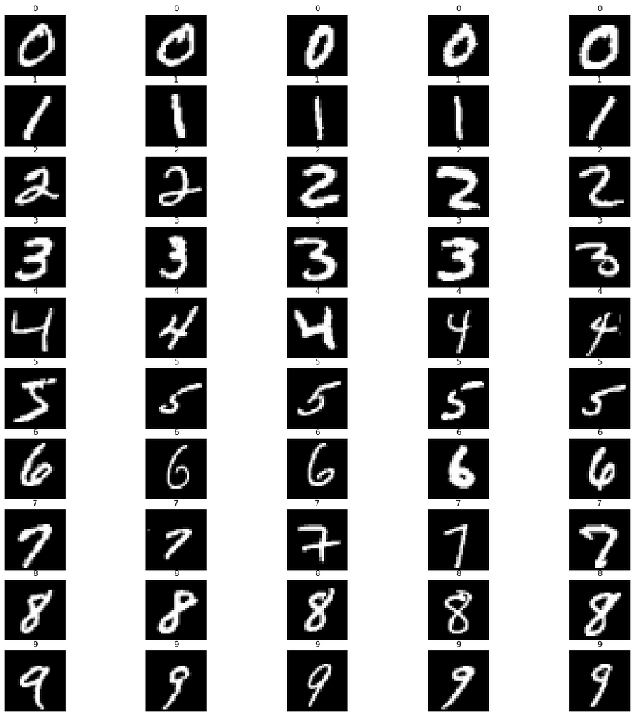

```python
images_by_digit = organize_data(x_train, y_train)
plot_images([images_by_digit[i//5][i%5] for i in range(50)], (str(i//5) for i in range(50)), 10)
```

### concat n images togther

```python
# Source: https://stackoverflow.com/a/30228789
import numpy as np

def concat_images(*images):
    if len(images) == 0:
        return None

    imgs_comb = np.hstack(images)
    return imgs_comb
```

### Build 3dig data

```python
import random
# 000 : 4000 picutres
# 001:  4000 picures

def build_data_set():
    def create_random_triplet_images(first_digit, second_digit, third_digit):
        first_digit_images = images_by_digit[first_digit]
        second_digit_images = images_by_digit[second_digit]
        third_digit_images = images_by_digit[third_digit]
        # return [concat_images(*image) for image, _ in zip(itertools.product(images_by_digit[0], images_by_digit[1], images_by_digit[0]), range(4000))]
        return ([concat_images(random.choice(first_digit_images),
                                random.choice(second_digit_images),
                                random.choice(third_digit_images))
                                for _ in range(4000)])

    data_set = []
    for number in range(101):
        data_set.append(create_random_triplet_images(number // 100, (number // 10) % 10, number % 10))
    return data_set

%time digit_triplets = build_data_set()
```

```
CPU times: user 5.33 s, sys: 567 ms, total: 5.9 s
Wall time: 5.87 s
```

### Present dataset samples

```
4000
```

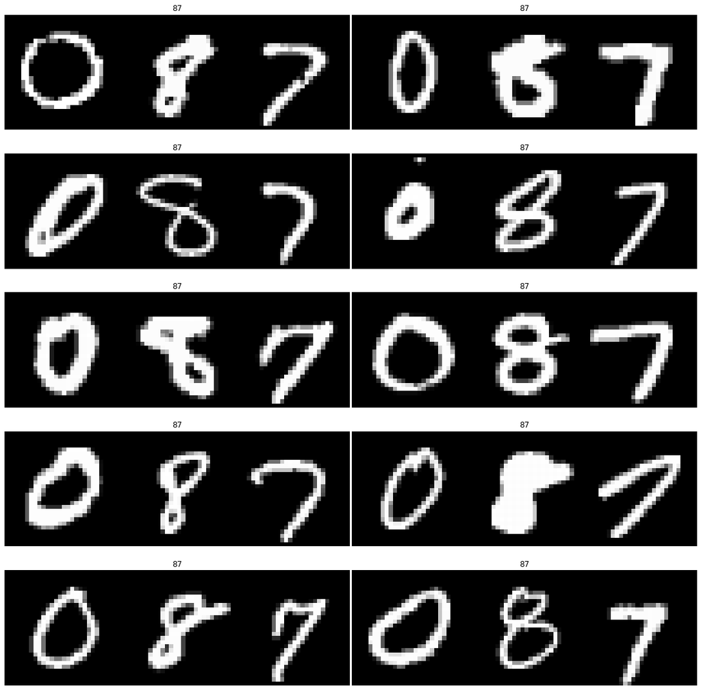

```python
random_number = random.randint(0, 100)
plot_images([digit_triplets[random_number][i] for i in range(10)], (str(random_number) for _ in range(10)), 5, padding=0.3)
len(digit_triplets[random_number]) # 4000 :)
```

# End of Submisn1

### Building Dataset

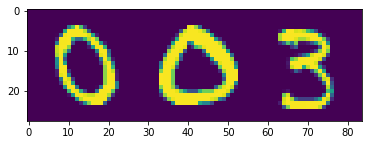

```python
plt.imshow(digit_triplets[3][3])
```

```python
def split_dataset_to_X_y_arrays(data):
    all_data_tupple = []
    for number in range(len(data)): #101 numbers
        for img in (data[number]):
            all_data_tupple.append((img, number))

    # convert to NP.array
    all_data_tupple = np.array(all_data_tupple)

    # shuffle
    random.shuffle(all_data_tupple) # Give it a g00d shuffle


    X = all_data_tupple[:, 0]
    y = all_data_tupple[:, 1]
    return X, y


def split_dataset_3way(X, y,validation_size = 0.30 ,test_size = 0.10):
    """Will Split the data to Train, Test and Validation  """
    # for example: 90% to training [= 0.1]
    X_train, X_test, y_train, y_test = train_test_split(X, y, test_size = test_size)
    # from that 90%, 10% will go to [ validation = 0.1 ]
    X_train, X_validation, y_train, y_validation = train_test_split(X_train, y_train, test_size = validation_size)
    # will leave us with:
    # 10% - Test
    # 81% - Train
    # 9% - Validation
    return X_train, X_validation, X_test, y_train, y_validation, y_test



all_X, all_y = split_dataset_to_X_y_arrays(digit_triplets)

X_train, X_valid, X_test, y_train, y_valid, y_test = split_dataset_3way(all_X, all_y, validation_size = 0.30 ,test_size = 0.10)
print(f'\n\nX_train:{len(X_train)}, X_valid:{len(X_valid)}, X_test:{len(X_test)},\
    y_train:{len(y_train)}, y_valid:{len(y_valid)}, y_test:{len(y_test)}')
```

```
X_train:254520, X_valid:109080, X_test:40400,    y_train:254520, y_valid:109080, y_test:40400
```

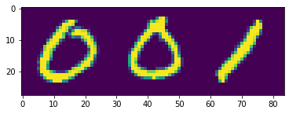

```python
plt.imshow(X_train[5])
```

```python
# Must inherate from dataset
class mnist_3dig_DataSet(Dataset):
    def __init__(self, x_train, y_train, transforms=None):
        super(mnist_3dig_DataSet,self).__init__()
        self.x_train = x_train
        self.y_train = y_train
        self.transforms = transforms


    def __getitem__(self, idx):
        x = self.x_train[idx] / self.x_train[idx].max()
        y = self.y_train[idx]
        if self.transforms:
            x = self.transforms(image=x.numpy())['image']

                # [Channel , H , W] -> Into The Network -> [Batch, Channel, Hight, Width]
        return x[np.newaxis, :, :], y

    def __len__(self):
        return len(self.x_train)
```

```python
# Taking only the first 600 values

mnist_3dig_train = mnist_3dig_DataSet(X_train[:3000], y_train[:3000], transforms=None)
mnist_3dig_test = mnist_3dig_DataSet(X_test[:3000],y_test[:3000], transforms=None)
mnist_3dig_val =  mnist_3dig_DataSet(X_valid[:3000], y_valid[:3000], transforms=None)
```

### Building Pytorch's DataLodaer

```python
BS=32
mnist_3dig_loader_train = DataLoader(dataset = mnist_3dig_train, batch_size = BS, shuffle=True)
mnist_3dig_loader_test = DataLoader(dataset = mnist_3dig_test, batch_size = BS, shuffle=True)
mnist_3dig_loader_val = DataLoader(dataset = mnist_3dig_val, batch_size = BS, shuffle=True)
```

## Building LeNet

```python
class LeNetModel_3dig(nn.Module):

    """input size: [1(greyScale),84(width),28(height)]"""
    def __init__(self):
        super(LeNetModel_3dig, self).__init__()
        # 1 input image channel, 6 output channels, 3x3 square convolution
        # kernel
        self.conv1 = nn.Conv2d(1, 6, 5)
        self.conv2 = nn.Conv2d(6, 16, 5)
        # an affine operation: y = Wx + b
        self.fc1 = nn.Linear(1152, 120)  # fixme
        self.fc2 = nn.Linear(120, 84)
        self.fc3 = nn.Linear(84, 101)

    def forward(self, x):
        x = F.relu(self.conv1(x))
        x = F.max_pool2d(x, 2) # 84x28 -> 42x14
        x = F.relu(self.conv2(x))
        x = F.max_pool2d(x, 2) # 42x14 -> 21x7
        # print(f'line17: x = {x}')
        x = x.view(x.shape[0], -1)
        # print(f'line19: x = {x}')
        x = F.relu(self.fc1(x))
        # print(f'line22 well well')
        x = F.relu(self.fc2(x))
        x = self.fc3(x)
        return x
```

```python
lenet_model_3dig = LeNetModel_3dig()
criterion = torch.nn.CrossEntropyLoss()
optimizer = optim.Adam(lenet_model_3dig.parameters(), lr = 0.001, betas = (0.9, 0.999), eps = 1e-08, weight_decay=0, amsgrad=False)
```

```python
def train_one_epoch(dataloader , model, optimizer, epoc, criterion):
    accuracy = AverageMeter()
    losses = AverageMeter()
    model.train()



    for i, (image, target) in enumerate(dataloader):
        image = image.float() # float() will work better with pytorch (np.float will not run on the gpu)
        target = target.long()
        optimizer.zero_grad()
        output = model(image) # forward pass

        loss = criterion(output, target) # Calculate loss
        loss.backward() # Calculate the derivetive

        optimizer.step() # will modify our network according to the new values.


        pred = output.argmax(dim = 1, keepdim = True) # getting the element with the highest probability
        acc = torchmetrics.functional.accuracy(pred, target) # reading the accuracy of the network
        losses.update(loss.item(), image.size(0))
        accuracy.update(acc, image.size(0))


    return losses.avg, accuracy.avg
```

```python
def inference_one_epoch(dataloader , model, epoc, criterion):
    accuracy = AverageMeter()
    losses = AverageMeter()
    model.eval()



    for i, (images, targets) in enumerate(dataloader):
        images = images.float() # float() will work better with pytorch (np.float will not run on the gpu)
        targets = targets.long()
        # optimizer.zero_grad()
        output = model(images) # forward pass

        loss = criterion(output, targets) # Calculate loss



        pred = output.argmax(dim = 1, keepdim = True) # getting the element with the highest probability
        acc = torchmetrics.functional.accuracy(pred, targets) # reading the accuracy of the network
        losses.update(loss.item(), images.size(0))
        accuracy.update(acc, images.size(0))


    return losses.avg, accuracy.avg
```

```python
NUM_OF_EPOCS = 50
from tqdm import tqdm
def train_n_epochs(num_f_epocs = NUM_OF_EPOCS):
    acc_train_dict = []
    loss_train_dict = []
    acc_val_dict = []
    loss_val_dict = []


    for i in tqdm(range(num_f_epocs)):
        loss_train, accuracy_train = train_one_epoch(mnist_3dig_loader_train, lenet_model_3dig, optimizer, i, criterion)
        loss_train_dict.append(loss_train)
        acc_train_dict.append(accuracy_train)

        loss_val, accuracy_val = inference_one_epoch(mnist_3dig_loader_val, lenet_model_3dig, i, criterion)
        loss_val_dict.append(loss_val)
        acc_val_dict.append(accuracy_val)


    print(f'\nloss_train = {loss_train}')
    print(f'accuracy_train {accuracy_train}\n\n')
    print(f'\nloss_val= {loss_val}')
    print(f'accuracy_val {accuracy_val}\n\n')
    return (loss_train_dict, acc_train_dict), (loss_val_dict, acc_val_dict)

(loss_train_dict, acc_train_dict),(loss_val_dict, acc_val_dict) = train_n_epochs()
```

```
loss_train = 7.283685969620516e-08
accuracy_train 1.0



loss_val= 1.7548115108807882
accuracy_val 0.8629999756813049
```

[figure not shown]

```python
plt.plot(range(NUM_OF_EPOCS), loss_train_dict, 'g', label='loss_t')
plt.plot(range(NUM_OF_EPOCS), acc_train_dict, 'b', label='Accuracy_t')
plt.title('Train Loss & Accuracy')
plt.xlabel('Epochs')
plt.ylabel('Loss')
plt.legend()
plt.show()
```

[figure not shown]

```python
plt.plot(range(NUM_OF_EPOCS), loss_val_dict, 'r', label='loss_v')
plt.plot(range(NUM_OF_EPOCS), acc_val_dict, 'p', label='Accuracy_v')
plt.title('Validation Loss & Accuracy')
plt.xlabel('Epochs')
plt.ylabel('Loss')
plt.legend()
plt.show()
```

## TL;DR

In this lab we've learned how to build our own model from scratch, load into it our own made data, and train the model over it.

### Export to html notebook:

```python
%%shell

jupyter nbconvert --to html /content/CV2021B_Asmnt1.ipynb
```

```
[NbConvertApp] Converting notebook /content/CV2021B_Asmnt1.ipynb to html
[NbConvertApp] Writing 2441064 bytes to /content/CV2021B_Asmnt1.html
```

# References:

### Check Validation accuracy

```python
# def inference_date(dataloader , model, optimizer, epoc, criterion):
#     accuracy = AverageMeter()
#     losses = AverageMeter()
#     model.train()



#     for i, (image, target) in enumerate(dataloader):
#         image = image.float() # float() will work better with pytorch (np.float will not run on the gpu)
#         target = target.long()
#         optimizer.zero_grad()
#         output = model(image) # forward pass

#         loss = criterion(output, target) # Calculate loss
#         # loss.backward() # Calculate the derivetive



#         pred = output.argmax(dim = 1, keepdim = True) # getting the element with the highest probability
#         acc = torchmetrics.functional.accuracy(pred, target) # reading the accuracy of the network
#         losses.update(loss.item(), image.size(0))
#         accuracy.update(acc, image.size(0))


#     return losses.avg, accuracy.avg

# losses, accuracy = inference_date(mnist_3dig_loader_val, lenet_model_3dig, optimizer, 1, criterion)
# print(f'loss = {losses} , acc = {accuracy} ')
```

[output not shown]

```python
# def inference_single_image(single_image = mnist_3dig_val[1][0][0]):
#     plt.imshow(single_image)
#     image_batched = single_image[np.newaxis, :]
#     image_batched = torch.tensor(image_batched)
#     # image_batched = single_image.float() # float() will work better with pytorch (np.float will not run on the gpu)
#     # target = target.long()

#     optimizer.zero_grad()
#     output = model(image_batched) # forward pass
#     pred = output.argmax(dim = 1, keepdim = True) # getting the element with the highest probability

#     return pred




# BS=1
# mnist_3dig_loader_test_single = DataLoader(dataset = mnist_3dig_test, batch_size = BS, shuffle=False)

# print(mnist_3dig_loader_test_single.next())
```

[output not shown]

### Save pytorch's state

```python
def saveTorchState(epoch_num :int , model_state, optim_state, checkpoint_name = "torchCheckPoint" ):
    checkpoint = {
        "epoch":epoch_num, # An integer
        "model_state": model_state,  #model.state_dict(),
        "optim_state": optim_state #optimizer.state_dict()
    }

    torch.save(checkpoint, "torchCheckPoint.pth")


def loadTorchState(file_name = "torchCheckPoint.pth"):
    loaded_checkpoint = torch.load(file_name)
    epoch = loaded_checkpoint["epoch"]

    # we must create our model again
    model = Model(n_input_features=6)
    optimizer = optim.Adam(lenet_model_3dig.parameters(), lr = 0.001, betas = (0.9, 0.999), eps = 1e-08, weight_decay=0, amsgrad=False)

    model.load_state_dict(checkpoint["model_state"])
    optimizer.load_state_dict(checkpoint["optim_state"])

    return epoch, model, optimizer


# ######## When using GPU (cuda) ########

# # ___ Save on GPU & Load on CPU ___
# #save
# device = torch.device("cuda")
# model.to(device)
# torch.save(model.state_dict(),PATH)

# #load
# device = torch.device("cpu")
# model = Model(*args, **kwargs)
# model.load_state_dict(torch.load(PATH, map_location=device))

# # ___ Both save & load on GPU ___
# #save
# device = torch.device("cuda")
# model.to(device)
# torch.save(model.state_dict(),PATH)

# #load
# model = Model(*args, **kwargs)
# model.load_state_dict(torch.load(PATH))
# device = torch.device("cpu")

# # ___ Save on CPU & Load on GPU ___
# #save
# torch.save(model.state_dict(), PATH)

# #load
# device = torch.device("cuda")
# model = Model(*args, **kwargs)
# model.load_state_dict(torch.load(PATH, map_location="cuda:0"))
# model.to(device)
```

### Save& Load pytorch's State